# Contents

## Preamble

Qualtrics is a very powerful survey creation tool that disguises itself very well for the amount of depth it affords. It can create simple 1-page forms with ease, as well as very complicated API web calls across software. As an aspiring behavioral scientisit, I though it would be helpful to document my most used tools as well as some helpful functions that researchers would be most likely to benefit from. These would be most helpful for those that have a beginner understanding of Qualtrics.

## Condition Assignment

I personally like to work within the survey flow for the majority of my condition assignment. As a refresher, the survey flow gives you an overview of your `blocks` whereas the `survey builder` gives you an overview of your individual questions. By utilizing the survey flow, we can tell immediately how many conditions we have and the differences between the conditions.

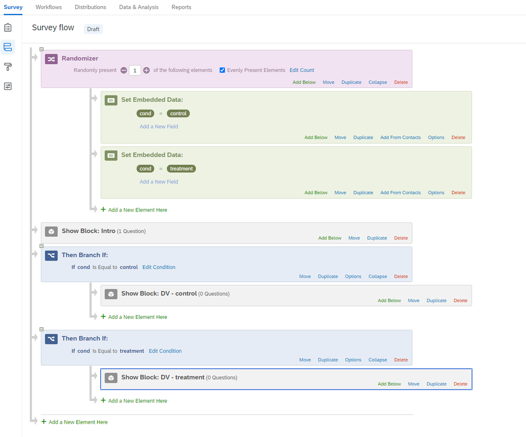

Condition Assignment via Survey Flow

The above picture shows two conditions `Control` and `Treatment` with simple random assignment. Following the randomization, each group will be displayed their corresponding set of DVs. On the backend, each individual response will have a new column labeled `cond` that will help with analysis.

This type of condition assignment is my most used, however, one drawback here is that we have to create separate blocks per each condition. Depending on how many conditions or how large the blocks are, this method may be quite tedious. An alternative is to assign the *differences* between the conditions in the variable declaration. As you'll see below, the variable creation is very flexible and we can assign short and long strings, numbers, and even pictures. (For pictures, you just need to make sure that they are uploaded to Qualtrics and retrieve the link)

[figure not shown]

Condition assignment within the variable

We've now successfully eliminated the need for multiple blocks while still utilizing the survey flow for condition assignment.